# Лабораторная работа № 4

Дискреционное разграничение прав в Linux. Расширенные атрибуты

Хамдамова А. А.

Российский университет дружбы народов, Москва, Россия

29 марта 2024

# Информация

## Докладчик

- Хамдамова Айжана Абдукаримовна
- студент Факультета Физико-математических и естесственных наук
- Российский университет дружбы народов
- 1032225989@pfur.ru
- https://github.com/AizhanaKhamdamova/study_2023-2024_infosec

# Вводная часть

## Теоретическая справка (1)

Права доступа определяют, какие действия конкретный пользователь может или не может совершать с определенным файлами и каталогами. С помощью разрешений можно создать надежную среду — такую, в которой никто не может поменять содержимое ваших документов или повредить системные файлы. [1]

## Теоретическая справка (2)

Расширенные атрибуты файлов Linux представляют собой пары имя:значение, которые постоянно связаны с файлами и каталогами, подобно тому как строки окружения связаны с процессом. Атрибут может быть определён или не определён. Если он определён, то его значение может быть или пустым, или не пустым. [2]

## Виды расширенных атрибутов

chattr +a # только добавление. Удаление и переименование запрещено;

chattr +A # не фиксировать данные об обращении к файлу

chattr +c # сжатый файл

chattr +d # неархивируемый файл

chattr +i # неизменяемый файл

chattr +S # синхронное обновление

chattr +s # безопасное удаление, (после удаления место на диске переписывается нулями)

chattr +u # неудаляемый файл

chattr -R # рекурсия

## Цели и задачи

- получить практические навыки работы в консоли с атрибутами файлов для групп пользователей.

## Ход работы

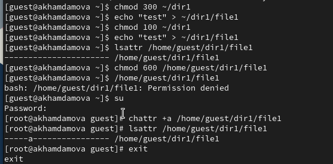

1-5

## Ход работы

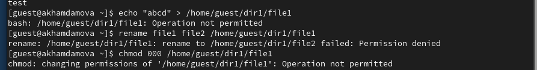

## Результаты

- удалось провести все операции в консоли
- получила практические навыки работы в консоли с атрибутами файлов для групп пользователей.

## Итоговый слайд

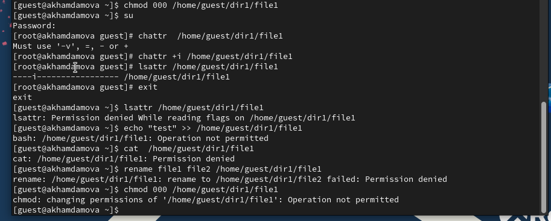